# Case Study 7: It’s about time

## Conclusion

I would greatly recommend investing time and money into Hot Diggity as their revenue performance as well as consistency in sales speaks for itself.

Note: I noticed a plot on somebody else’s repo that seems to indicate upward growth in Le Belle across weeks. I should look into this as it could change my conclusion. EDIT: I interpreted the other person’s graphic incorrectly due to poor labeling. A plot of the trend of sale amount over each day may indicate upward trend in LeBelle that may point toward investing here as they may continue to see growth.

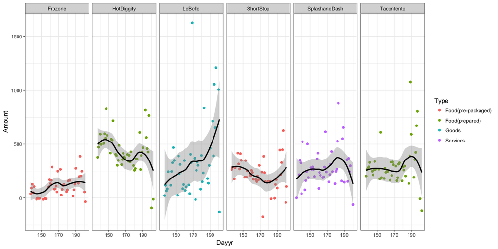

```r
clean.dat.day <- clean.dat %>%
  group_by(Name, Type, yday(Time), weekdays(Time, abbreviate = TRUE)) %>%
  summarise(Amount = sum(Amount), na.rm = TRUE) %>%
  rename(Dayyr = `yday(Time)`, Day = `weekdays(Time, abbreviate = TRUE)`)

clean.dat.day %>%
  filter(Dayyr > 125) %>%
  ggplot(aes(y = Amount, x = Dayyr, col = Type)) +
    geom_point() +
    geom_smooth(color = "black") +
    facet_grid(. ~ Name) +
    theme_bw()
```